# Determining the number of diatom valves to count per sample of the Lake Ioannina MIS 7–9 diatom record

# 1. Introduction

It is necessary to decide upon the minimum number of diatom valves to count per sample so as to achieve an acceptable level of accuracy whilst optimising efficiency. This document reports on the analyses undertaken to determine how many diatom valves should be counted per sample of the Lake Ioannina MIS 7-9 diatom record.

Battarbee (1986) explains that the number of diatom valves that should be counted per sample varies according to the purpose of the analysis and the ability to achieve statistical precision, the latter being a function of the structure of the diatom assemblage itself (e.g. a sample dominated by a single taxon would require a higher count in order for low numbers of rare taxa to be statistically reliable). Based on the relationship between the change in percentage abundance of individual taxa and the number of valves counted, Battarbee (1986) goes on to recommend a count of 300–600 valves per sample for routine analyses. There has been no change to this recommended count over the years; Battarbee et al. (2001) also recommend a count of 300–600 valves per sample for most analyses, and this has remained the standard practice across palaeolimnological investigations.

Two types of data have been collected:

- Detailed counts were obtained for three slides chosen at random, whereby the taxon name of each valve was recorded in the order it was counted.
- An initial low-resolution “skeleton” record of 15 samples was counted to gain some early insights into what the diatom record would look like. Based on previous diatom analyses of the I-284 core, a minimum of 500 valves were counted for each of these samples. As it was thought that the full count of 500 valves might not be necessary, these counts were tallied at three stages: after 300, 400 and 500 valves had been counted.

# 2. Import packages and data

```r
library(readxl)
library(purrr)
library(readr)
library(tools)
library(ggplot2)
library(dplyr)
library(tidyr)

# Create function that reads in a worksheet from an excel file then writes
# it to csv for longevity.
read_then_csv <- function(sheet, path) {
  path %>%
    read_excel(sheet = sheet) %>%
    write_csv(paste0("data/csv/imported-", sheet, ".csv"))
}

# Execute function and iterate over all worksheets in excel file.
path <- "data/count-justification-data.xlsx"

imported <- path %>%
  excel_sheets() %>%
  set_names() %>%
  map(read_then_csv, path = path)

# Set ggplot theme.
theme_set(theme_minimal())
theme_update(
  legend.box.background = element_rect(fill = "white",
                                       colour = "lightgrey"),
  legend.key.height = unit(0.4, "cm"),
  legend.key.width = unit(1, "cm")
)
```

# 3. Analyses

Two types of data exploration have been performed on these data:

- how relative abundances of individual taxa vary as the number of valves counted is increased.
- how relative abundances each life mode (planktonic, facultative planktonic and benthic) varies as the number of valves counted is increased.

## 3.1 Individual taxa

These analyses investigate whether the percentage relative abundances of selected taxa vary as the valve count is increased. This is the same analysis that Battarbee (1986) used to illustrate that 300 to 600 valves should be counted per sample. It is helpful to perform this analysis on the I-284 data as there could be an underlying assemblage structure specific to the Ioannina diatom assemblage that influences the point at which the abundances stabilise, which would dictate whether the lower or higher end of the recommended range should be used here.

### 3.1.1 Breakdown of results per valve counted

As figures 1, 2 and 3 demonstrate, there is some movement in the percentage relative abundances as the count progresses right up to 500 valves. However, between counts of 300 and 500 valves, these movements are very small, on the order of a few percentage points. The point at which the percentages stabilise varies across samples with sample 529 requiring the largest count before stabilising (Figure 3).

#### Sample 17

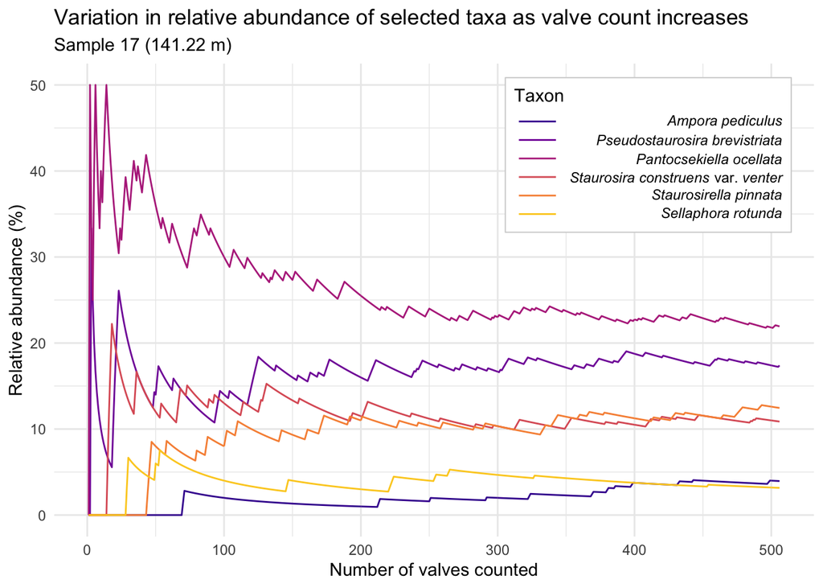

Figure 1: Variation in the percentage relative abundance of selected taxa as the number of valves counted is increased for I-284 core sample 17 (141.22 m).

```r
imported$s_17 %>%
  # Wrangle data to long (tidy) format.
  select(., all_of(c("valve_no",
                     "p_oc_pc",
                     "p_brev_pc",
                     "s_con_pc",
                     "s_pin_pc",
                     "a_ped_pc",
                     "s_rot_pc"))) %>%
  pivot_longer(., all_of(c("p_oc_pc",
                           "p_brev_pc",
                           "s_con_pc",
                           "s_pin_pc",
                           "a_ped_pc",
                           "s_rot_pc")),
               names_to = "taxon",
               names_transform = list(taxon = as.factor),
               values_to = "pc") %>%
  # Plot.
  ggplot(aes(x = valve_no,
           y = pc,
           colour = taxon)) +
  geom_line() +
  scale_colour_viridis_d(
    option = "C",
    begin = 0.1,
    end = 0.9,
    labels = c(expression(italic("Ampora pediculus")),
               expression(italic("Pseudostaurosira brevistriata")) ,
               expression(italic("Pantocsekiella ocellata")),
               expression(paste(italic("Staurosira construens"),
                                " var. ",
                                paste(italic("venter")))),
               expression(italic("Staurosirella pinnata")),
               expression(italic("Sellaphora rotunda")))) +
  labs(
    title = "Variation in relative abundance of selected taxa as valve count increases",
    subtitle = "Sample 17 (141.22 m)",
    colour = "Taxon") +
  xlab("Number of valves counted") +
  ylab("Relative abundance (%)") +
  theme(
    legend.position = c(0.97, 0.97),
    legend.justification = c("right", "top"),
  )
```

#### Sample 33

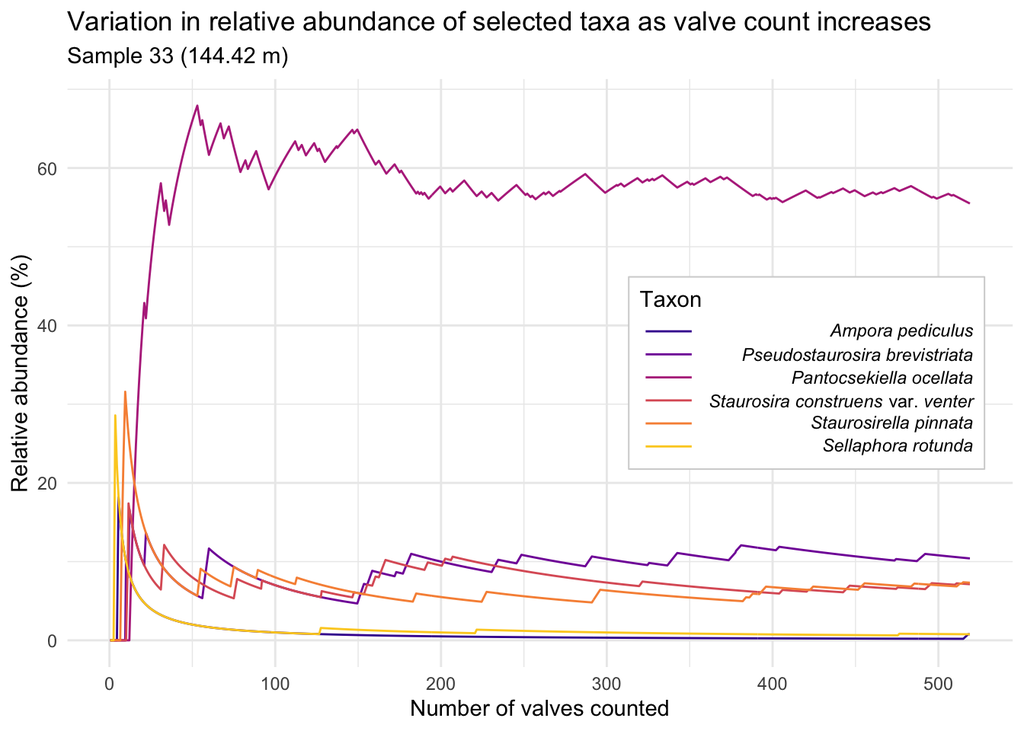

Figure 2: Variation in the percentage relative abundance of selected taxa as the number of valves counted is increased for I-284 core sample 33 (144.42 m).

```r
imported$s_33 %>%
  # Wrangle data to long (tidy) format.
  select(., all_of(c("valve_no",
                     "p_oc_pc",
                     "p_brev_pc",
                     "s_con_pc",
                     "s_pin_pc",
                     "a_ped_pc",
                     "s_rot_pc"))) %>%
  pivot_longer(., all_of(c("p_oc_pc",
                           "p_brev_pc",
                           "s_con_pc",
                           "s_pin_pc",
                           "a_ped_pc",
                           "s_rot_pc")),
               names_to = "taxon",
               names_transform = list(taxon = as.factor),
               values_to = "pc") %>%
  # Plot.
  ggplot(aes(x = valve_no,
             y = pc,
             colour = taxon)) +
  geom_line() +
  scale_colour_viridis_d(
    option = "C",
    begin = 0.1,
    end = 0.9,
    labels = c(expression(italic("Ampora pediculus")),
               expression(italic("Pseudostaurosira brevistriata")) ,
               expression(italic("Pantocsekiella ocellata")),
               expression(paste(italic("Staurosira construens"),
                                " var. ",
                                paste(italic("venter")))),
               expression(italic("Staurosirella pinnata")),
               expression(italic("Sellaphora rotunda")))) +
  labs(
    title = "Variation in relative abundance of selected taxa as valve count increases",
    subtitle = "Sample 33 (144.42 m)",
    colour = "Taxon") +
  xlab("Number of valves counted") +
  ylab("Relative abundance (%)") +
  theme(
    legend.position = c(0.97, 0.5),
    legend.justification = c("right", "center"),
  )
```

#### Sample 529

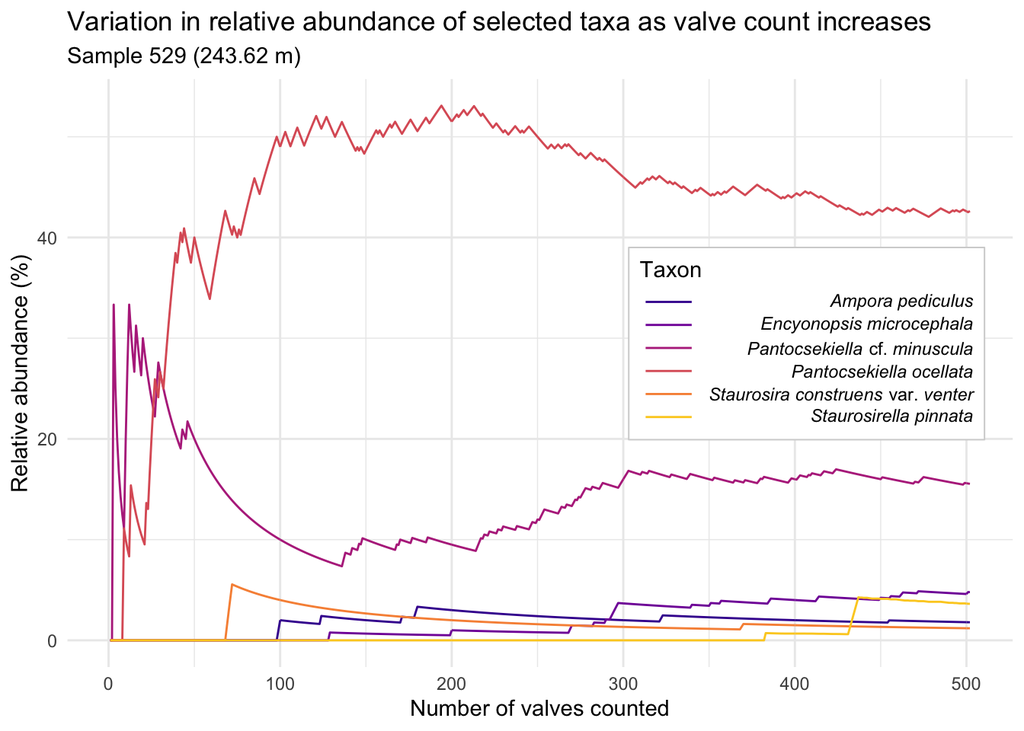

Figure 3: Variation in the percentage relative abundance of selected taxa as the number of valves counted is increased for I-284 core sample 529 (243.62 m).

```r
imported$s_529 %>%
  # Wrangle data to long (tidy) format.
  select(., all_of(c("valve_no",
                     "p_min_pc",
                     "p_oc_pc",
                     "s_con_pc",
                     "s_pin_pc",
                     "a_ped_pc",
                     "e_mic_pc"))) %>%
  pivot_longer(., all_of(c("p_min_pc",
                           "p_oc_pc",
                           "s_con_pc",
                           "s_pin_pc",
                           "a_ped_pc",
                           "e_mic_pc")),
               names_to = "taxon",
               names_transform = list(taxon = as.factor),
               values_to = "pc") %>%
  # Plot.
  ggplot(aes(x = valve_no,
             y = pc,
             colour = taxon)) +
  geom_line() +
  scale_colour_viridis_d(
    option = "C",
    begin = 0.1,
    end = 0.9,
    labels = c(expression(italic("Ampora pediculus")),
               expression(italic("Encyonopsis microcephala")) ,
               expression(paste(italic("Pantocsekiella"),
                                " cf. ",
                                paste(italic("minuscula")))),
               expression(italic("Pantocsekiella ocellata")),
               expression(paste(italic("Staurosira construens"),
                                " var. ",
                                paste(italic("venter")))),
               expression(italic("Staurosirella pinnata")))) +
  labs(
    title = "Variation in relative abundance of selected taxa as valve count increases",
    subtitle = "Sample 529 (243.62 m)",
    colour = "Taxon") +
  xlab("Number of valves counted") +
  ylab("Relative abundance (%)") +
  theme(
    legend.position = c(0.97, 0.55),
    legend.justification = c("right", "center"),
  )
```

### 3.1.2 Breakdown of results at 300, 400 and 500 valves counted

A less granular breakdown across numerous samples is displayed on a facet plot (Figure 4). The relatively straight lines of the plots demonstrate that there is little change in the percentages as counting progresses.

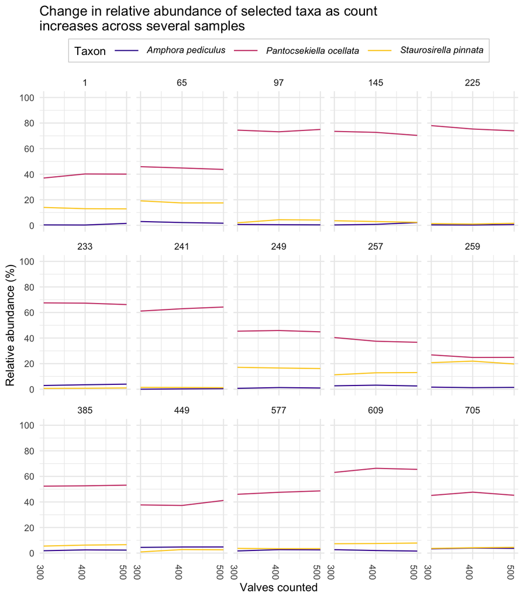

Figure 4: Variation in the percentage relative abundance of selected taxa as the number of valves counted is increased from 300 to 400 to 500 valves for selected I-284 core samples.

```r
imported$hundreds_taxa %>%
  ggplot(aes(x = count,
             y = pc_ab,
             colour = taxon)) +
  geom_line() +
  scale_colour_viridis_d(
    option = "C",
    labels = c(expression(italic("Amphora pediculus")),
               expression(italic("Pantocsekiella ocellata")),
               expression(italic("Staurosirella pinnata"))),
    begin = 0.1,
    end = 0.9) +
  facet_wrap("sample_no", ncol = 5) +
  scale_x_continuous(limits = c(300, 500),
                     breaks = seq(300, 500, 100)) +
  scale_y_continuous(limits = c(0, 100),
                     breaks = seq(0, 100, 20)) +
  labs(
    title = "Change in relative abundance of selected taxa as count
increases across several samples",
    colour = "Taxon") +
  xlab("Valves counted") +
  ylab("Relative abundance (%)") +
  theme(
    legend.position = "top",
    axis.text.x = element_text(angle = 270)
  )
```

For each line on the facet plots, the changes in relative abundance between a count of 300 to 400 valves, a count of 400 to 500 valves and a count of 300 to 500 valves have been calculated. The changes are summarised by the statistics below. There is a mean difference in the relative abundances of these taxa of only 1.3 percentage points between a count of 300 valves and a count of 500 valves. The largest difference is 4.1 percentage points, which is very small and would probably not change any interpretation that might be made from an analysis of the assemblage.

```r
dif_300_400 <- with(imported$hundreds_taxa,
                    abs(pc_ab[count=="400"] - pc_ab[count=="300"]))

dif_400_500 <- with(imported$hundreds_taxa,
                    abs(pc_ab[count=="500"] - pc_ab[count=="400"]))

dif_300_500 <- with(imported$hundreds_taxa,
                    abs(pc_ab[count=="500"] - pc_ab[count=="300"]))

differences_taxa <- tibble("300 to 400 valves" = dif_300_400,
                           "400 to 500 valves" = dif_400_500,
                           "300 to 500 valves" = dif_300_500)

summary(differences_taxa)
```

```
##  300 to 400 valves 400 to 500 valves 300 to 500 valves
##  Min.   :0.07363   Min.   :0.02168   Min.   :0.1164
##  1st Qu.:0.33208   1st Qu.:0.17678   1st Qu.:0.3870
##  Median :0.62303   Median :0.42639   Median :1.0587
##  Mean   :0.99016   Mean   :0.72305   Mean   :1.2912
##  3rd Qu.:1.54902   3rd Qu.:1.09963   3rd Qu.:1.8404
##  Max.   :3.21124   Max.   :3.92647   Max.   :4.0570
```

## 3.2 Life mode

The intention is for the results of the diatom analysis to be used to reconstruct the past lake environment with a particular emphasis on lake level change. The variations in the relative abundances of planktonic, facultative planktonic and benthic taxa (i.e. diatom life mode or habitat) are most useful in reconstructing such changes. It was therefore deemed useful to see how these abundances vary as a function of number of valves counted.

### 3.2.1 Breakdown of results per valve counted

Figures 5, 6 and 7 show that the relative abundances all stabilise by a count of 250 valves, but that this number also varies between samples. Whilst a count of 250 valves would have been required for sample 17, counts of only 200 and 100 would have been sufficient for samples 33 and 529 respectively.

#### Sample 17

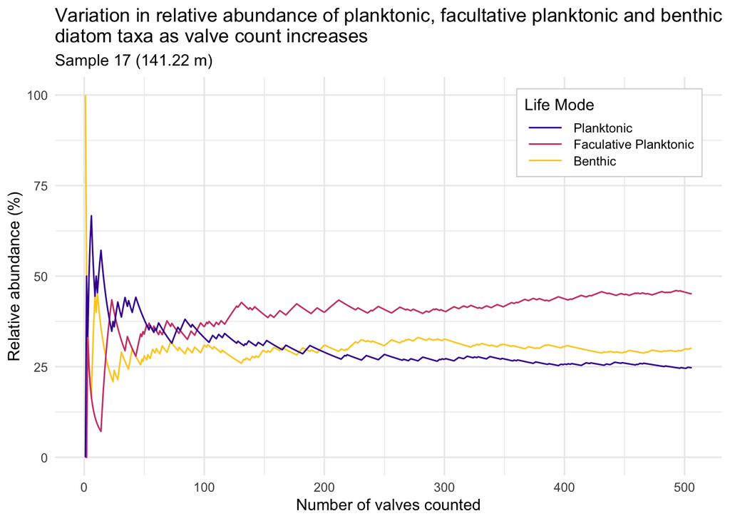

Figure 5: Variation in the percentage relative abundance of all diatom taxa grouped by life mode as the number of valves counted is increased for I-284 core sample 17 (141.22 m).

```r
imported$s_17 %>%
  # Wrangle data to long (tidy) format.
  select(., all_of(c("valve_no", "p_pc", "fp_pc", "b_pc"))) %>%
  pivot_longer(., all_of(c("p_pc", "fp_pc", "b_pc")),
             names_to = "life_mode",
             names_transform = list(life_mode = as.factor),
             values_to = "pc") %>%
  # Plot.
  ggplot(aes(x = valve_no,
             y = pc,
             colour = life_mode)) +
  geom_line() +
  scale_colour_viridis_d(
    option = "C",
    begin = 0.9,
    end = 0.1,
    labels = c("Benthic", "Faculative Planktonic", "Planktonic"),
    guide = guide_legend(reverse = TRUE)) +
  labs(
    title = "Variation in relative abundance of planktonic, facultative planktonic and benthic
diatom taxa as valve count increases",
    subtitle = "Sample 17 (141.22 m)",
    colour = "Life Mode") +
  xlab("Number of valves counted") +
  ylab("Relative abundance (%)") +
  theme(
    legend.position = c(0.97, 0.97),
    legend.justification = c("right", "top"),
  )
```

#### Sample 33

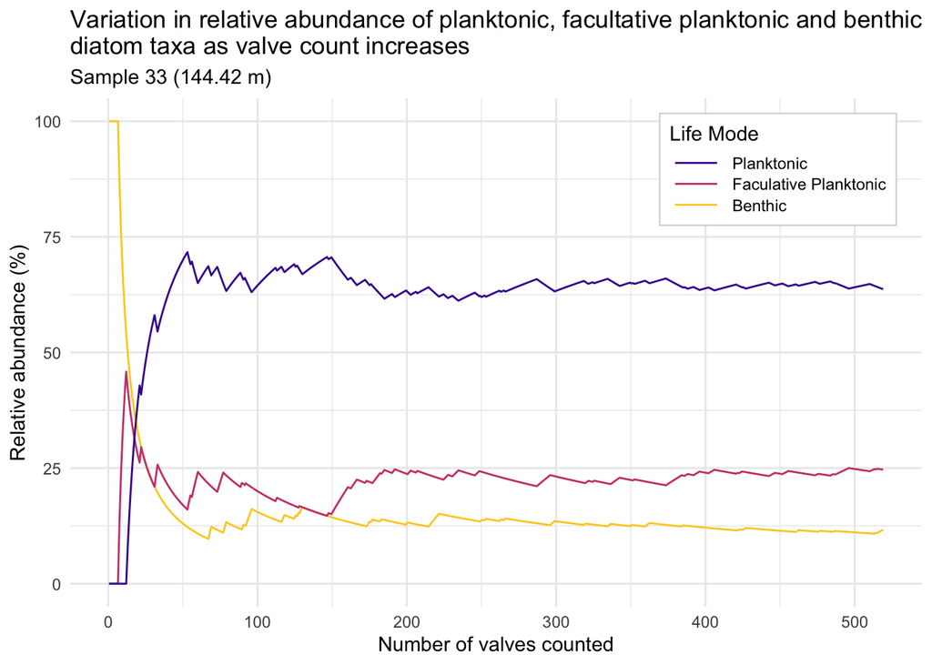

Figure 6: Variation in the percentage relative abundance of all diatom taxa grouped by life mode as the number of valves counted is increased for I-284 core sample 33 (144.42 m).

```r
imported$s_33 %>%
  # Wrangle data to long (tidy) format.
  select(., all_of(c("valve_no", "p_pc", "fp_pc", "b_pc"))) %>%
  pivot_longer(., all_of(c("p_pc", "fp_pc", "b_pc")),
             names_to = "life_mode",
             names_transform = list(life_mode = as.factor),
             values_to = "pc") %>%
  # Plot data.
  ggplot(aes(x = valve_no,
             y = pc,
             colour = life_mode)) +
  geom_line() +
  scale_colour_viridis_d(
    option = "C",
    begin = 0.9,
    end = 0.1,
    labels = c("Benthic", "Faculative Planktonic", "Planktonic"),
    guide = guide_legend(reverse = TRUE)) +
  labs(
    title = "Variation in relative abundance of planktonic, facultative planktonic and benthic
diatom taxa as valve count increases",
    subtitle = "Sample 33 (144.42 m)",
    colour = "Life Mode") +
  xlab("Number of valves counted") +
  ylab("Relative abundance (%)") +
  theme(
    legend.position = c(0.97, 0.97),
    legend.justification = c("right", "top"),
  )
```

#### Sample 529

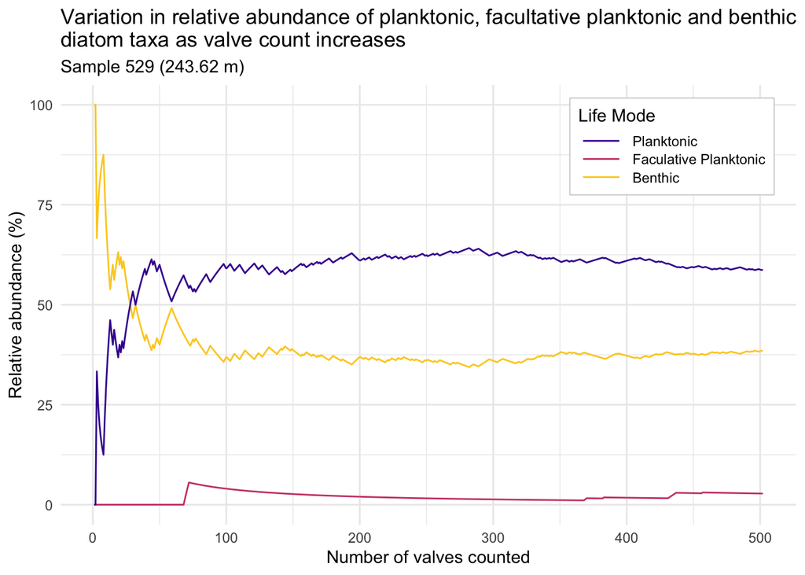

Figure 7: Variation in the percentage relative abundance of all diatom taxa grouped by life mode as the number of valves counted is increased for I-284 core sample 529 (243.62 m).

```r
imported$s_529 %>%
  # Wrangle data to long (tidy) format.
  select(., all_of(c("valve_no", "p_pc", "fp_pc", "b_pc"))) %>%
  pivot_longer(., all_of(c("p_pc", "fp_pc", "b_pc")),
             names_to = "life_mode",
             names_transform = list(life_mode = as.factor),
             values_to = "pc") %>%
  # Plot data.
  ggplot(aes(x = valve_no,
             y = pc,
             colour = life_mode)) +
  geom_line() +
  scale_colour_viridis_d(
    option = "C",
    begin = 0.9,
    end = 0.1,
    labels = c("Benthic", "Faculative Planktonic", "Planktonic"),
    guide = guide_legend(reverse = TRUE)) +
  labs(
    title = "Variation in relative abundance of planktonic, facultative planktonic and benthic
diatom taxa as valve count increases",
    subtitle = "Sample 529 (243.62 m)",
    colour = "Life Mode") +
  xlab("Number of valves counted") +
  ylab("Relative abundance (%)") +
  theme(
    legend.position = c(0.97, 0.97),
    legend.justification = c("right", "top"),
  )
```

### 3.2.2 Breakdown of results at 300, 400 and 500 valves counted

The results of section 3.2.1 demonstrated that a count of 250 valves should be sufficient to obtain an accurate representation of the percentage abundances of diatom taxa grouped by life mode. However, it also showed that the point at which the percentages stabilised varies across samples. It is sensible to check whether the percentages are stable across increasing valve counts in more samples before deciding if a lower count is going to be acceptable.

A less granular breakdown of counts (at 300, 400 and 500 valves) was carried out on 15 samples throughout the length of the core section. Figure 8 shows that the percentage relative abundance is very stable across counts of 300, 400 and 500 valves. Relative abundances of planktonic, facultative planktonic and benthic taxa vary by only a few percentage points as the count progresses.

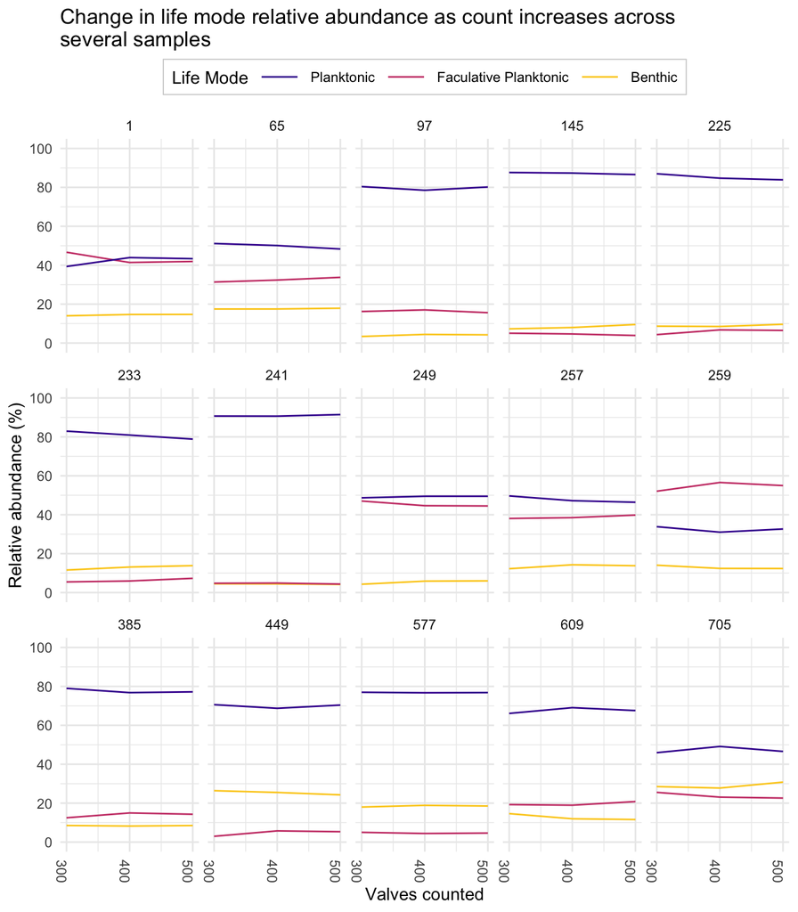

Figure 8: Variation in the percentage relative abundance of all taxa grouped by life mode as the number of valves counted is increased from 300 to 400 to 500 valves for selected I-284 core samples.

```r
imported$hundreds_life_mode %>%
  ggplot(aes(x = count,
             y = pc_ab,
             colour = life_mode)) +
  geom_line() +
  scale_colour_viridis_d(
    option = "C",
    begin = 0.9,
    end = 0.1,
    labels = c("Benthic", "Faculative Planktonic", "Planktonic"),
    guide = guide_legend(reverse = TRUE)) +
  facet_wrap("sample_no", ncol = 5) +
  scale_x_continuous(limits = c(300, 500),
                     breaks = seq(300, 500, 100)) +
  scale_y_continuous(limits = c(0, 100),
                     breaks = seq(0, 100, 20)) +
  labs(
    title = "Change in life mode relative abundance as count increases across
several samples",
    colour = "Life Mode") +
  xlab("Valves counted") +
  ylab("Relative abundance (%)") +
  theme(
    legend.position = "top",
    axis.text.x = element_text(angle = 270)
  )
```

For each line on the facet plots, the changes in relative abundance between a count of 300 to 400 valves, a count of 400 to 500 valves and a count of 300 to 500 valves have been calculated. The changes are summarised by the statistics below. These statistics confirm that the relative abundances remain stable as the count progresses. There is a mean change across all variables of only 1.7 percentage points as the count is increased from 300 to 500 valves. The maximum change is 4.7 percentage points, which is so small that it would not affect any interpretation of past lake level from the planktonic to benthic ratio.

```r
dif_300_400 <- with(imported$hundreds_life_mode,
                    abs(pc_ab[count=="400"] - pc_ab[count=="300"]))

dif_400_500 <- with(imported$hundreds_life_mode,
                    abs(pc_ab[count=="500"] - pc_ab[count=="400"]))

dif_300_500 <- with(imported$hundreds_life_mode,
                    abs(pc_ab[count=="500"] - pc_ab[count=="300"]))

differences_life_mode <- tibble("300 to 400 valves" = dif_300_400,
                      "400 to 500 valves" = dif_400_500,
                      "300 to 500 valves" = dif_300_500)

summary(differences_life_mode)
```

```
##  300 to 400 valves 400 to 500 valves  300 to 500 valves
##  Min.   :0.01425   Min.   :0.006228   Min.   :0.02118
##  1st Qu.:0.47436   1st Qu.:0.339730   1st Qu.:0.72507
##  Median :1.06607   Median :0.715180   Median :1.70691
##  Mean   :1.55891   Mean   :0.900081   Mean   :1.68788
##  3rd Qu.:2.42511   3rd Qu.:1.440707   3rd Qu.:2.36352
##  Max.   :5.27076   Max.   :3.035093   Max.   :4.72818
```

# 4. Conclusion

This document has investigated changes in the percentage relative abundances of selected diatom taxa and changes in the percentage relative abundances of all diatom taxa grouped by life mode as the number of diatom valves counted is increased. It demonstrates that a diatom valve count of 300 valves per sample is sufficient to achieve the aims of the diatom analyses.

The abundances of taxa grouped by life mode stabilise by a count of 250 valves in the three samples investigated in detail. Less granular counts (at 300, 400 and 500 valves) of multiple samples also showed little change in the relative abundances of taxa grouped by life mode. These samples were taken from the full length of the core section so probably encapsulate the majority of the diatom assemblage variation to be found in the new diatom record. However, it is still possible that some samples might have an assemblage that requires a higher count so it is best to be cautious and count the minimum 300 valves recommended by Battarbee (1986) rather than 250.

# References

Battarbee, R. W. (1986) Diatom analysis. In Berglund, B. E. (ed) *Handbook of* *Holocene palaeoecology and palaeohydrology*. Chichester: John Wiley & Sons.

Battarbee, R. W., Jones, V. J., Flower, R. J., Cameron, N. G., Bennion, H., Carvalho, L. & Juggins, S. (2001) Diatoms. In Smol, J. P., Birks, H. J. B. & Last, W. M. (eds) *Tracking environmental change using lake sediments, Volume* *3: Terrestrial, algal, and siliceous indicators*. Dordrecht: Kluwer Academic Publishers, 155–202.

Jones, T. D. (2010) *A reconstruction of late Pleistocene and Holocene lake* *level change at Ioannina, northwest Greece*. PhD thesis. University of Leeds.

Loakes, K. L., (2015) *Late Quaternary Palaeolimnology and Environmental Change* *in the South Wollo Highlands, Ethiopia*. PhD thesis. Loughborough University.

Loakes, K. L., Ryves, D. B., Lamb, H. F., Schäbitz, F., Dee, M., Tyler, J. J., Mills, K. & McGowan, S. (2018) *Late Quaternary climate change in the* *north-eastern highlands of Ethiopia: a high resolution 15,600 year diatom and* *pigment record from Lake Hayk*. Quaternary Science Reviews, 202, 166–181.

Soeprobowati, T. R., Tandjung, S. D., Sutikno, S., Hadissusanto, S., & Gell, P. (2016) *The minimum number of valves for diatom identification in Rawapening* *Lake, central Java*. Biotropia, 23, 96–104.

Stevenson, R. J., Pan, Y. & Van Dam, H. (2010) Assessing environmental conditions in rivers and streams with diatoms. In Smol, J. P. & Stoermer, E. F. (eds) *The Diatoms: applications for the Environmental and Earth Sciences*, Cambridge: Cambridge University Press, 57–85.

Wilson, G. P., Reed, J. M., Lawson, I. T., Frogley, M. R., Preece, R. C. & Tzedakis, P. C. (2008) *Diatom response to the Last Glacial–Interglacial* *Transition in the Ioannina basin, northwest Greece: implications for* *Mediterranean palaeoclimate reconstruction*. Quaternary Science Reviews, 27, 428–440.

Wilson, G. P., Frogley, M. R., Roucoux, K. H., Jones, T. D., Leng, M. J., Lawson, I. T. & Hughes, P. D. (2013) *Limnetic and terrestrial responses to* *climate change during the onset of the penultimate glacial stage in NW Greece*. Global and Planetary Change, 107, 213–225.

Wilson, G. P., Reed, J. M., Frogley, M. R., Hughes, P. D. & Tzedakis, P. C. (2015) *Reconciling diverse lacustrine and terrestrial system response to* *penultimate deglacial warming in southern Europe*. Geology, 43(9), 819–822.

Wilson, G. P., Frogley, M. R., Hughes, P. D., Roucoux, K. H., Margari, V., Jones, T. D., Leng, M. J. & Tzedakis, P. C. (2021) *Persistent millennial-scale* *climate variability in Southern Europe during Marine Isotope Stage 6*. Quaternary Science Advances, 3, 1–10.